# Coursera NOAA Storm Analysis: Most Harmful Events

Seth Dimick

11/8/2017

## Synopsis

The NOAA storm dataset is used here in order to judge the most harmful storm events in the US in terms of population health and economic consequence. To do this, the relevant data is aggregated for the observable time frame by event type. Aggregate measures taken include the following:

- occurances = total documentations of event type
- total.fatalities = the total fatalities documented due to event type
- mean.fatalities = the average fatalities per documented occurance of event type
- total.injuries = the total injuries documented due to event type
- mean.injuries = the average injuries per documented occurance of event type
- total.damage = the total monetary damage due to event type
- mean.damage = the average monetary damage per documented occurance of event type

In regards to population health, the top ten events by total injuries and by total fatalies are taken and visualized by number of occuances and average number of injuries and fatalities per occurance. Likewise, for economic consequence, the top ten events by total monetary damage are visualized by number of occurances and average monetary damage per occurance.

The purpose of the visualizations are to allow the interpreter to easily sort these harmful events by frequency, impact per occurance, or total impact over time.

*Note: The visualizations use a log scales for the x and y axes in order to provide more visual separation.*

## Data Processing

The data is downloaded, loaded, cleaned, and aggregated in a straight forward fashion. The zip file of NOAA data is downloaded from the provided Coursera download link and can be read into R with the `read.csv()` function directly without modification.

**Data Download and Import**

```r
# load libraries
library(dplyr)
library(ggplot2)

# download, unzip and load raw data (using curl method arg for macbook)
download.file("https://d396qusza40orc.cloudfront.net/repdata%2Fdata%2FStormData.csv.bz2", "StormData.csv.bz2", method = "curl")
RawData <- read.csv("StormData.csv.bz2")
```

The data set is then cleaned up a bit by limitting the data the 50 US states, excluding any monetary exponential codes that do not follow the [Storm Data Documentation](https://d396qusza40orc.cloudfront.net/repdata%2Fpeer2_doc%2Fpd01016005curr.pdf), removing any event types that contain the “summary” in name, and the white space is trimmed off the event types.

**Cleaning Data**

```r
# select variables of interest and
# filter out undocumented damange exponent indicators
# and non-states
exp.codes <- c("","k","K","m","M","b","B")
states <- c("AL","AK","AZ","AR","CA","CO","CT","DE","FL","GA",
            "HI","ID","IL","IN","IA","KS","KY","LA","ME","MD",
            "MA","MI","MN","MS","MO","MT","NE","NV","NH","NJ",
            "NM","NY","NC","ND","OH","OK","OR","PA","RI","SC",
            "SD","TN","TX","UT","VT","VA","WA","WV","WI","WY")
CleanData <- RawData %>%
  select(STATE,
         EVTYPE,
         FATALITIES,
         INJURIES,
         PROPDMG,
         PROPDMGEXP,
         CROPDMG,
         CROPDMGEXP) %>%
  filter(PROPDMGEXP %in% c("","k","K","m","M","b","B"),
         CROPDMGEXP %in% c("","k","K","m","M","b","B"),
         STATE %in% states)

# trim event type names and convert to uppercase
CleanData$EVTYPE <- trimws(toupper(CleanData$EVTYPE))

# remove "event types" that are date summaries
CleanData <- CleanData %>%
  filter(!grepl("SUMMARY", EVTYPE))
```

Finally, we create our aggregated measures for each event type. The first step of this process is to “exponentiate” the property and crop damage by the “thousands”, “millions”, or “billions” indicators and sum them into a **total** monetary damage measure. Following this we can aggregate total and average injuries, fatalities, and monetary damage by event type.

**Create Aggregate Measures**

```r
# "exponentiate" the crop and property damage and create total damage variable
CleanData$PROPERTY.DAMAGE <-
  ifelse(CleanData$PROPDMGEXP%in%c("b","B"),CleanData$PROPDMG*1000000000,
         ifelse(CleanData$PROPDMGEXP%in%c("m","M"),CleanData$PROPDMG*1000000,
                ifelse(CleanData$PROPDMGEXP%in%c("k","K"),CleanData$PROPDMG*1000,
                       CleanData$PROPDMG)))
CleanData$CROP.DAMAGE <-
  ifelse(CleanData$CROPDMGEXP%in%c("b","B"),CleanData$CROPDMG*1000000000,
         ifelse(CleanData$CROPDMGEXP%in%c("m","M"),CleanData$CROPDMG*1000000,
                ifelse(CleanData$CROPDMGEXP%in%c("k","K"),CleanData$CROPDMG*1000,
                       CleanData$CROPDMG)))
CleanData$TOTAL.DAMAGE <- CleanData$PROPERTY.DAMAGE + CleanData$CROP.DAMAGE

# aggregate data by event type
CleanData <- CleanData %>%
  group_by(EVTYPE) %>%
  summarise(occurances = n(),
            total.fatalities = sum(FATALITIES),
            mean.fatalities = mean(FATALITIES),
            total.injuries = sum(INJURIES),
            mean.injuries = mean(INJURIES),
            total.damage = sum(TOTAL.DAMAGE),
            mean.damage = mean(TOTAL.DAMAGE)) %>%
  as.data.frame()
```

## Results

### Most Harmful Event for Population Health

#### Most Injuries

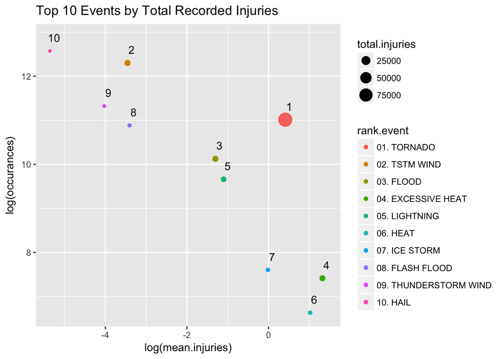

```r
injuries <- CleanData %>%
  select(EVTYPE,
         occurances,
         total.injuries,
         mean.injuries) %>%
  top_n(10, total.injuries) %>%
  mutate(
    rank = rank(total.injuries*-1, ties.method = "first")
  ) %>%
  mutate(rank.event = paste0(
    ifelse(rank<10,"0",""),rank,". ", EVTYPE))

injuries %>%
  ggplot(aes(x = log(mean.injuries), y=log(occurances), label=rank)) +
  geom_point(aes(color=rank.event,
             size=total.injuries)) +
  geom_text(nudge_x = 0.1, nudge_y = 0.3) +
  ggtitle("Top 10 Events by Total Recorded Injuries")
```

```r
injuries %>% select(
  rank,
  EVTYPE,
  total.injuries,
  occurances,
  mean.injuries
) %>% arrange(rank)
```

```
##    rank            EVTYPE total.injuries occurances mean.injuries
## 1     1           TORNADO          91321      60611   1.506673706
## 2     2         TSTM WIND           6941     219812   0.031576984
## 3     3             FLOOD           6786      24951   0.271973067
## 4     4    EXCESSIVE HEAT           6209       1658   3.744873341
## 5     5         LIGHTNING           5212      15678   0.332440362
## 6     6              HEAT           2100        758   2.770448549
## 7     7         ICE STORM           1975       2003   0.986020969
## 8     8       FLASH FLOOD           1767      53259   0.033177491
## 9     9 THUNDERSTORM WIND           1471      82474   0.017835924
## 10   10              HAIL           1358     288578   0.004705833
```

#### Most Fatalities

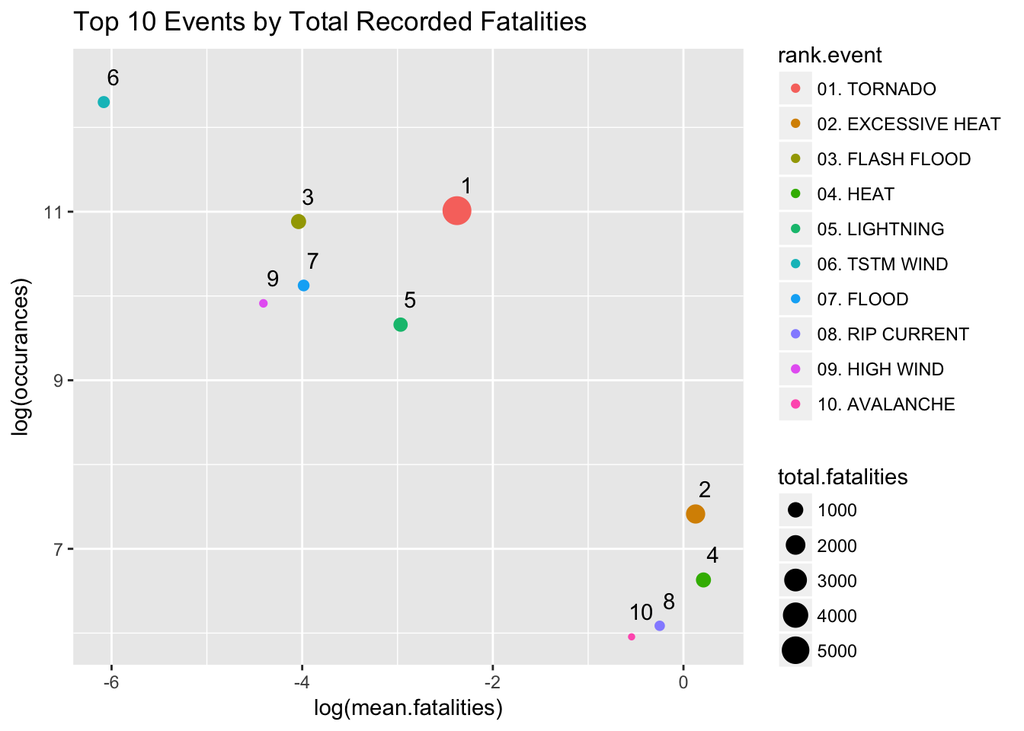

```r
fatalities <- CleanData %>%
  select(EVTYPE,
         occurances,
         total.fatalities,
         mean.fatalities) %>%
  top_n(10, total.fatalities) %>%
  mutate(
    rank = rank(total.fatalities*-1, ties.method = "first")
  ) %>%
  mutate(rank.event = paste0(
    ifelse(rank<10,"0",""),rank,". ", EVTYPE))

fatalities %>%
  ggplot(aes(x = log(mean.fatalities), y=log(occurances), label=rank)) +
  geom_point(aes(color=rank.event,
             size=total.fatalities)) +
  geom_text(nudge_x = 0.1, nudge_y = 0.3) +
  ggtitle("Top 10 Events by Total Recorded Fatalities")
```

```r
fatalities %>% select(
  rank,
  EVTYPE,
  total.fatalities,
  occurances,
  mean.fatalities
) %>% arrange(rank)
```

```
##    rank         EVTYPE total.fatalities occurances mean.fatalities
## 1     1        TORNADO             5630      60611      0.09288743
## 2     2 EXCESSIVE HEAT             1883       1658      1.13570567
## 3     3    FLASH FLOOD              939      53259      0.01763082
## 4     4           HEAT              935        758      1.23350923
## 5     5      LIGHTNING              806      15678      0.05140962
## 6     6      TSTM WIND              502     219812      0.00228377
## 7     7          FLOOD              464      24951      0.01859645
## 8     8    RIP CURRENT              343        440      0.77954545
## 9     9      HIGH WIND              246      20179      0.01219089
## 10   10      AVALANCHE              224        386      0.58031088
```

### Greatest Economic Consequences

#### Most Monetary Damage

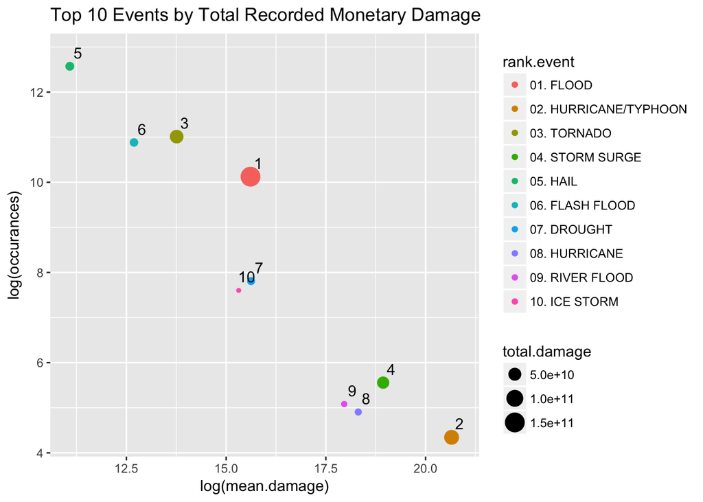

```r
damage <- CleanData %>%
  select(EVTYPE,
         occurances,
         total.damage,
         mean.damage) %>%
  top_n(10, total.damage) %>%
  mutate(
    rank = rank(total.damage*-1, ties.method = "first")
  ) %>%
  mutate(rank.event = paste0(
    ifelse(rank<10,"0",""),rank,". ", EVTYPE))

damage %>%
  ggplot(aes(x = log(mean.damage), y=log(occurances),
             label=rank)) +
  geom_point(aes(size=total.damage, color=rank.event)) +
  geom_text(nudge_x = 0.2, nudge_y = 0.3) +
  ggtitle("Top 10 Events by Total Recorded Monetary Damage")
```

```r
damage %>% select(
  rank,
  EVTYPE,
  total.damage,
  occurances,
  mean.damage
) %>% arrange(rank)
```

```
##    rank            EVTYPE total.damage occurances  mean.damage
## 1     1             FLOOD 150145287257      24951   6017606.00
## 2     2 HURRICANE/TYPHOON  71636600800         77 930345464.94
## 3     3           TORNADO  57301462593      60611    945397.08
## 4     4       STORM SURGE  43323466000        259 167272069.50
## 5     5              HAIL  18733209230     288578     64915.58
## 6     6       FLASH FLOOD  17274535167      53259    324349.60
## 7     7           DROUGHT  15013467000       2460   6103035.37
## 8     8         HURRICANE  12103928010        135  89658726.00
## 9     9       RIVER FLOOD  10148401000        161  63033546.58
## 10   10         ICE STORM   8967017810       2003   4476793.71
```